# **Tutorial on the NBA: Are you paid to win?**

### By SyedHadi Jaffrey, Aneesha Tamang, and Diya Thangada

**Introduction**

The NBA is a multi-billion dollar industry, having world-reknown players as household names, like Michael Jordan, LeBron James, and Stephen Curry. Throughout history we've seen our fair share of basketball icons, incredibly-performing players, and even badly-performing players. However, just because a player performs well or badly, does that mean that they'll be paid appropriately per their skills? In this tutorial, we will explore this.

For this tutorial, we will be analyzing NBA Players and Salaries and if having a greater salary will correlate to a player contributing to more wins.

We hypothesize that having a greater salary will correlate to a player contributing to more wins.

# **Data Collection/Curation**

```python
import pandas as pd
import numpy as np
import math
import matplotlib.pyplot as plt
import seaborn as sns
import scipy
from scipy import stats
from matplotlib.pyplot import figure
from sklearn.discriminant_analysis import LinearDiscriminantAnalysis
import warnings
warnings.filterwarnings('ignore')

players = pd.read_csv("https://raw.githubusercontent.com/jaffeh/cmsc320_fproject_files/main/players.csv")
salaries = pd.read_csv("https://raw.githubusercontent.com/jaffeh/cmsc320_fproject_files/main/salaries_1985to2018.csv")
```

In the players dataset, there are 25 columns:

- index
- _id: unique id to identify player
- birthDate
- birthPlace
- career_AST: Assists throughout career
- career_FG%: Field goal percentage for their career
- career_FG3%: Field goal for three's percentage for their career
- career_FT%: Free throw percentage throughout career
- career_G: Games played throughout career
- career_PER: Player efficiency rating for their career
- career_PTS: Player's points throughout career
- career_TRB: Player's total rebounds for their career
- career_WS: Player's win share (contribution to a win) during their career
- career_eFG%: Player's effective field goal percentage for their career
- college
- draft_pick: order in which they were picked for a team during draft
- draft_round: which round they got drafted in
- draft_team: which team they got drafted to
- draft_year: which year they got drafted
- height
- highSchool
- name
- position: which position in basketball the player plays
- shoots: which hand they shoot from
- weight

Non-descriptory column titles are self explanatory.

The players dataset has two columns that will be useful for our analysis: "**career_PER**" and "**career_WS**" (player efficiency rating and win shares); primarily career win shares, though.

```python
players.head()
```

|  | index | _id | birthDate | birthPlace | career_AST | career_FG% | career_FG3% | career_FT% | career_G | career_PER | ... | draft_pick | draft_round | draft_team | draft_year | height | highSchool | name | position | shoots | weight |
| --- | --- | --- | --- | --- | --- | --- | --- | --- | --- | --- | --- | --- | --- | --- | --- | --- | --- | --- | --- | --- | --- |
| 0 | 0 | abdelal01 | June 24, 1968 | Cairo, Egypt | 0.3 | 50.2 | 0.0 | 70.1 | 256 | 13.0 | ... | 25th overall | 1st round | Portland Trail Blazers | 1990 | 6-10 | Bloomfield in Bloomfield, New Jersey | Alaa Abdelnaby | Power Forward | Right | 240lb |
| 1 | 1 | abdulza01 | April 7, 1946 | Brooklyn, New York | 1.2 | 42.8 | NaN | 72.8 | 505 | 15.1 | ... | 5th overall | 1st round | Cincinnati Royals | 1968 | 6-9 | John Jay in Brooklyn, New York | Zaid Abdul-Aziz | Power Forward and Center | Right | 235lb |
| 2 | 2 | abdulka01 | April 16, 1947 | New York, New York | 3.6 | 55.9 | 5.6 | 72.1 | 1560 | 24.6 | ... | 1st overall | 1st round | Milwaukee Bucks | 1969 | 7-2 | Power Memorial in New York, New York | Kareem Abdul-Jabbar | Center | Right | 225lb |
| 3 | 3 | abdulma02 | March 9, 1969 | Gulfport, Mississippi | 3.5 | 44.2 | 35.4 | 90.5 | 586 | 15.4 | ... | 3rd overall | 1st round | Denver Nuggets | 1990 | 6-1 | Gulfport in Gulfport, Mississippi | Mahmoud Abdul-Rauf | Point Guard | Right | 162lb |
| 4 | 4 | abdulta01 | November 3, 1974 | Maisons Alfort, France | 1.1 | 41.7 | 23.7 | 70.3 | 236 | 11.4 | ... | 11th overall | 1st round | Sacramento Kings | 1997 | 6-6 | Lycee Aristide Briand in Evreux, France | Tariq Abdul-Wahad | Shooting Guard | Right | 223lb |

5 rows × 25 columns

In the salaries dataset, there are 8 columns:

- index
- league
- player_id
- salary
- season
- season_end
- season_start
- team

The titles are self explanatory.

```python
salaries.head()
```

|  | index | league | player_id | salary | season | season_end | season_start | team |
| --- | --- | --- | --- | --- | --- | --- | --- | --- |
| 0 | 0 | NBA | abdelal01 | 395000 | 1990-91 | 1991 | 1990 | Portland Trail Blazers |
| 1 | 1 | NBA | abdelal01 | 494000 | 1991-92 | 1992 | 1991 | Portland Trail Blazers |
| 2 | 2 | NBA | abdelal01 | 500000 | 1992-93 | 1993 | 1992 | Boston Celtics |
| 3 | 3 | NBA | abdelal01 | 805000 | 1993-94 | 1994 | 1993 | Boston Celtics |
| 4 | 4 | NBA | abdelal01 | 650000 | 1994-95 | 1995 | 1994 | Sacramento Kings |

**Data Management: Tidying and Modifying the Data**

Here we are grouping the salary information by teams for easier organization.

```python
team_sal = salaries.groupby('team')
team_sal['salary']
```

```
<pandas.core.groupby.generic.SeriesGroupBy object at 0x00000267F3334190>
```

Now, we will combine the datasets for easier analysis later on, and drop unnecessary columns.

The merged dataset has 7 columns

- index_x
- _id
- career_PER
- career_WS
- salary
- season
- team

(See previous descriptions of column names)

```python
#Combine players and salaries dataset
combined_df = players.merge(salaries, left_on='_id', right_on='player_id')
combined_df = combined_df.drop('league', axis=1)
combined_df = combined_df.drop('season_end', axis=1)
combined_df = combined_df.drop('season_start', axis=1)
combined_df = combined_df.drop('player_id', axis=1)
combined_df = combined_df.drop(combined_df.loc[:, 'career_eFG%':'weight'].columns, axis=1)
combined_df = combined_df.drop(combined_df.loc[:, 'birthDate':'career_G'].columns, axis=1)
combined_df = combined_df.drop(combined_df.loc[:, 'career_PTS':'career_TRB'].columns, axis=1)
combined_df = combined_df.drop('index_y', axis=1)


combined_df
```

|  | index_x | _id | career_PER | career_WS | salary | season | team |
| --- | --- | --- | --- | --- | --- | --- | --- |
| 0 | 0 | abdelal01 | 13.0 | 4.8 | 395000 | 1990-91 | Portland Trail Blazers |
| 1 | 0 | abdelal01 | 13.0 | 4.8 | 494000 | 1991-92 | Portland Trail Blazers |
| 2 | 0 | abdelal01 | 13.0 | 4.8 | 500000 | 1992-93 | Boston Celtics |
| 3 | 0 | abdelal01 | 13.0 | 4.8 | 805000 | 1993-94 | Boston Celtics |
| 4 | 0 | abdelal01 | 13.0 | 4.8 | 650000 | 1994-95 | Sacramento Kings |
| ... | ... | ... | ... | ... | ... | ... | ... |
| 14158 | 4679 | zipsepa01 | 6.1 | 0.0 | 750000 | 2016-17 | Chicago Bulls |
| 14159 | 4679 | zipsepa01 | 6.1 | 0.0 | 1312611 | 2017-18 | Chicago Bulls |
| 14160 | 4680 | zizican01 | 17.5 | 3.0 | 1645200 | 2017-18 | Cleveland Cavaliers |
| 14161 | 4683 | zubaciv01 | 17.6 | 5.3 | 1034956 | 2016-17 | Los Angeles Lakers |
| 14162 | 4683 | zubaciv01 | 17.6 | 5.3 | 1312611 | 2017-18 | Los Angeles Lakers |

14163 rows × 7 columns

Our data is now set up and tidied, so we can perform analysis on our datasets now.

# **Data Representation, Visualization and Exploratory Analysis**

Let's look at the salaries and player career win shares of all teams visually.

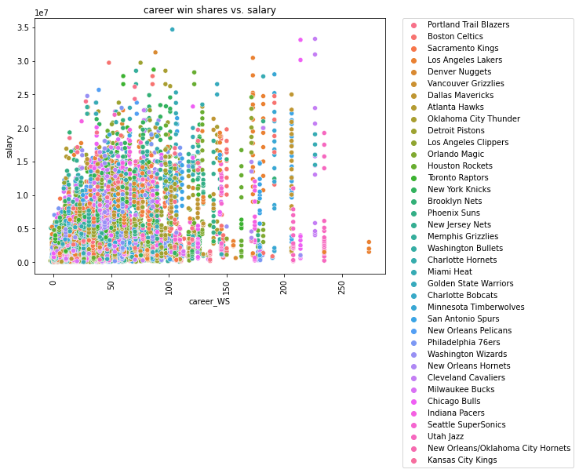

```python
combineddf_scatter = combined_df.copy()
figure(figsize=(8, 6))
float_ws = (combineddf_scatter['career_WS']).astype(float)
sns.scatterplot(x=float_ws, y="salary",hue='team', data=combineddf_scatter)
plt.xticks(rotation=90)
plt.title("career win shares vs. salary")
plt.legend(bbox_to_anchor=(1.05, 1), loc='upper left', borderaxespad=0)
plt.show()
```

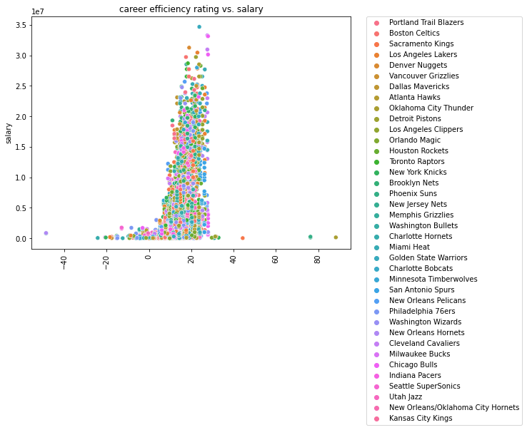

```python
figure(figsize=(8, 6))
#Dealing with missing data
float_per = np.where(combineddf_scatter['career_PER'] == '-', np.nan, combineddf_scatter['career_PER'])
float_per = (float_per).astype(float)
sns.scatterplot(x=float_per, y="salary",hue='team', data=combineddf_scatter)
plt.xticks(rotation=90)
plt.title("career efficiency rating vs. salary")
plt.legend(bbox_to_anchor=(1.05, 1), loc='upper left', borderaxespad=0)
plt.show()
```

**General Statistical Analysis:**

Min, Max, Mean, Median, Mode, and Standard Deviation for Players' Salaries and Win Shares

Let's take a general look at the highest paid player, average paid player, and lowest paid player's win shares for any differences or notable observations.

First, we need to find the Min, Max, Mean, Median, Mode, and Standard Deviation for Players' Salaries.

```python
import statistics as st
mean = np.mean(combined_df['salary'])
mode = st.mode(combined_df['salary'].values)
median = np.median(combined_df['salary'])
minimum = np.min(combined_df['salary'])
maximum = np.max(combined_df['salary'])
std_dev = np.std(combined_df['salary'])

print('Summary Statistics for Player Salaries')
print('Mean: ', mean, '\nMedian: ', median, '\nMode: ', mode, "\nMin: ", minimum, "\nMax: ", maximum,"\nStd Dev: ", std_dev)
```

```
Summary Statistics for Player Salaries
Mean:  3164870.1659959047
Median:  1500000.0
Mode:  1000000
Min:  2706
Max:  34682550
Std Dev:  4184898.165009826
```

Visually:

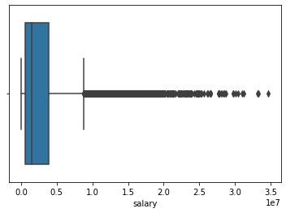

```python
sns.boxplot(x=(combined_df['salary']))
```

Now, let's look at the following:

Who's the player closest to the mean salary?

Who are the mode salary player(s)?

Who are the median salary player(s)?

Who are the minimum salary player(s)?

Who are the maximum salary player(s)?

```python
#Who's the player closest to the mean salary?
means = []
closest_val = min(combined_df['salary'], key=lambda x:abs(x-mean))
for index, row in combined_df.iterrows():
  if(row['salary'] == closest_val) and (row['_id'] not in means):
    means.append(row['_id'])

print("Player(s) closest to the mean salary:")
print(means)

#Who are the mode salary player(s)?
modes = []
for index, row in combined_df.iterrows():
  if(row['salary'] == mode) and (row['_id'] not in modes):
    modes.append(row['_id'])

print("Player(s) with the mode salary:")
print(modes)

#Who are the median salary player(s)?
medians = []
for index, row in combined_df.iterrows():
  if(row['salary'] == median) and (row['_id'] not in medians):
    medians.append(row['_id'])

print("Player(s) with the median salary:")
print(medians)

#Who are the minimum salary player(s)?
minimums = []
for index, row in combined_df.iterrows():
  if(row['salary'] == minimum) and (row['_id'] not in minimums):
    minimums.append(row['_id'])

print("Player(s) with the minimum salary:")
print(minimums)

#Who are the maximum salary player(s)?
maximums = []
for index, row in combined_df.iterrows():
  if(row['salary'] == maximum) and (row['_id'] not in maximums):
    maximums.append(row['_id'])

print("Player(s) with the maximum salary:")
print(maximums)
```

```
Player(s) closest to the mean salary:
['smithjo02']
Player(s) with the mode salary:
['anderro01', 'anthogr01', 'baileth01', 'barklch01', 'benjabe01', 'benoida01', 'besttr01', 'blakest01', 'brandel01', 'brockjo01', 'brownde01', 'bryanma01', 'buckngr01', 'burresc01', 'carran01', 'carrch01', 'cheanca01', 'cheekma01', 'chrisra01', 'clarkke01', 'corbity01', 'covinro01', 'crottjo01', 'cu…
Player(s) with the median salary:
['afflaar01', 'anthogr01', 'ayongu01', 'pendeje02', 'bareajo01', 'birdla01', 'blackro01', 'brickfr01', 'collija02', 'dawkijo01', 'dienetr01', 'duhonch01', 'edwarbl01', 'ellinwa01', 'ellisda01', 'englial01', 'evansma01', 'ewingpa01', 'farmajo01', 'floydsl01', 'forbega01', 'gillke01', 'greenac01', 'ho…
Player(s) with the minimum salary:
['sasseja01']
Player(s) with the maximum salary:
['curryst01']
```

Now, let's look at the following:

What's the mean salary player(s)' win share?

What's the mode salary player(s)' win share?

What's the median salary player(s)' win share?

What's the minimum salary player(s)' win share?

What's the maximum salary player(s)' win share?

```python
#What's the mean salary player(s)' win share?
means_ws = []
#Recording which players win shares we already stored
ws_alr_stored = []

for index, row in combined_df.iterrows():
  for person in means:
    if(row['_id'] == person) and (person not in ws_alr_stored):
      means_ws.append(row['career_WS'])
      ws_alr_stored.append(row['_id'])

print("Career win share of Player(s) closest to the mean salary:")
print(means_ws)

#What's the mode salary player(s)' win share?
modes_ws = []
#Recording which players win shares we already stored
ws_alr_stored = []

for index, row in combined_df.iterrows():
  for person in modes:
    if(row['_id'] == person) and (person not in ws_alr_stored):
      modes_ws.append(row['career_WS'])
      ws_alr_stored.append(row['_id'])

print("Career win share of Player(s) with the mode salary:")
print(modes_ws)

#What's the median salary player(s)' win share?
medians_ws = []
#Recording which players win shares we already stored
ws_alr_stored = []

for index, row in combined_df.iterrows():
  for person in medians:
    if(row['_id'] == person) and (person not in ws_alr_stored):
      medians_ws.append(row['career_WS'])
      ws_alr_stored.append(row['_id'])

print("Career win share of Player(s) with the median salary:")
print(medians_ws)

#What's the minimum salary player(s)' win share?
minimums_ws = []
#Recording which players win shares we already stored
ws_alr_stored = []

for index, row in combined_df.iterrows():
  for person in minimums:
    if(row['_id'] == person) and (person not in ws_alr_stored):
      minimums_ws.append(row['career_WS'])
      ws_alr_stored.append(row['_id'])

print("Career win share of Player(s) with the minimum salary:")
print(minimums_ws)

#What's the maximum salary player(s)' win share?
maximums_ws = []
#Recording which players win shares we already stored
ws_alr_stored = []

for index, row in combined_df.iterrows():
  for person in maximums:
    if(row['_id'] == person) and (person not in ws_alr_stored):
      maximums_ws.append(row['career_WS'])
      ws_alr_stored.append(row['_id'])

print("Career win share of Player(s) with the maximum salary:")
print(maximums_ws)
```

```
Career win share of Player(s) closest to the mean salary:
['60.3']
Career win share of Player(s) with the mode salary:
['24.2', '35.9', '45.0', '177.2', '32.7', '16.9', '30.9', '29.1', '109.6', '3.7', '33.4', '26.1', '20.9', '16.4', '42.1', '3.9', '23.1', '103.5', '0.5', '18.2', '56.5', '17.8', '12.1', '91.1', '41.5', '76.9', '32.9', '26.2', '86.2', '59.7', '0.1', '12.5', '48.9', '84.7', '21.8', '34.8', '44.7', '5.8…
Career win share of Player(s) with the median salary:
['33.5', '35.9', '5.1', '6.3', '23.1', '145.8', '75.6', '29.8', '1.9', '21.8', '5.6', '25.0', '24.2', '17.8', '84.7', '100.7', '21.7', '126.4', '13.9', '50.6', '1.7', '47.8', '99.5', '20.0', '-0.2', '91.8', '25.2', '15.1', '22.0', '5.0', '24.9', '75.4', '0.4', '4.4', '3.4', '19.7', '234.6', '179.1',…
Career win share of Player(s) with the minimum salary:
['0.0']
Career win share of Player(s) with the maximum salary:
['102.9']
```

Right off the bat, from these results we can observe that for the players with the mode salary, or most frequently appearing/most common salary, the career win shares of these players vary greatly. The same can be said about the career win shares for players with the median salary, or midpoint of the salaries.

We can further examine this by looking at the average/mean win share of players with the most common salary and midpoint salary, and the range of the salaries.

```python
#Average of career win shares for mode salary players
avg_modes = np.mean(list(map(float, modes_ws)))
print("Average of career win shares for mode salary players: " + str(avg_modes))
#Minimum career win share for mode salary players
min_modes = np.min(list(map(float, modes_ws)))
print("Minimum career win share for mode salary players: " + str(min_modes))
#Maximum career win share for mode salary players
max_modes = np.max(list(map(float, modes_ws)))
print("Maximum career win share for mode salary players: " + str(max_modes))
#Average of career win shares for median salary players
avg_medians = np.mean(list(map(float, medians_ws)))
print("Average of career win shares for median salary players: " + str(avg_medians))
#Minimum career win share for median salary players
min_medians = np.min(list(map(float, medians_ws)))
print("Minimum career win share for median salary players: " + str(min_medians))
#Maximum career win share for median salary players
max_medians = np.max(list(map(float, medians_ws)))
print("Maximum career win share for median salary players: " + str(max_medians))
```

```
Average of career win shares for mode salary players: 42.827407407407414
Minimum career win share for mode salary players: -0.8
Maximum career win share for mode salary players: 214.0
Average of career win shares for median salary players: 37.698412698412696
Minimum career win share for median salary players: -0.5
Maximum career win share for median salary players: 234.6
```

For further analysis, it's important to note mean, median, and mode are all measures of central tendency, which means a value meant to be representative of the data.

For the players with the most common salary, it's seen that the average amount of career win shares is about 42.8. However, the players' win shares vary from -0.8 to 214.0, a very stark range.

For the players with the midpoint salary, it's seen that the average amount of career win shares is about 37.7. However, the players' win shares vary from -0.5 to 234.6, also a very vast range.

This can be interpreted as that when MODE or MEDIAN is used as the measure of central tendency in the context of player salaries, when seeing if it's representative of a relationship between salary and win shares for this dataset when examining their corresponding player career win shares, it's hard to support if there is a relationship considering the massive range between their respective maximum and minimum career win shares.

How does this compare to the general statistics of win shares?

Let's do a General Statistical Analysis of Career Win Shares.

Min, Max, Mean, Median, Mode, and Standard Deviation for Players' Win Shares

```python
ws_mean = np.mean((combined_df['career_WS'].values).astype(float))
ws_mode = st.mode((combined_df['career_WS'].values).astype(float))
ws_median = np.median((combined_df['career_WS']).astype(float))
ws_minimum = np.min((combined_df['career_WS']).astype(float))
ws_maximum = np.max((combined_df['career_WS']).astype(float))
ws_std_dev = np.std((combined_df['career_WS']).astype(float))

print('Summary Statistics for Player Career Win Shares')
print('Mean: ', ws_mean, '\nMedian: ', ws_median, '\nMode: ', ws_mode, "\nMin: ", ws_minimum, "\nMax: ", ws_maximum,"\nStd Dev: ", ws_std_dev)
```

```
Summary Statistics for Player Career Win Shares
Mean:  35.35603332627268
Median:  23.5
Mode:  0.0
Min:  -2.7
Max:  273.4
Std Dev:  38.67095623554173
```

Visually in a box plot:

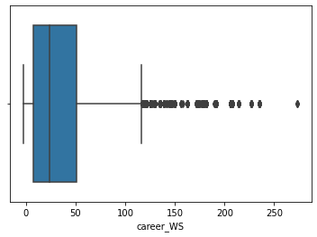

```python
sns.boxplot(x=(combined_df['career_WS']).astype(float))
```

**What can we observe about career win shares based on salary from these computations and visualizations?**

From our computations of the highest paid players, then their corresponding career win shares, here are our summary statistics:

Career win share of Player(s) closest to the mean salary: 60.3

(Average) Career win share of Player(s) with the mode salary: 42.827407407407414

(Average) Career win share of Player(s) with the median salary: 37.698412698412696

Career win share of Player(s) with the minimum salary: 0.0

Career win share of Player(s) with the maximum salary: 102.9

**Here is the reality of the summary statistics of player career win shares overall:**

Mean: 35.35603332627268

Median: 23.5

Mode: 0.0

Min: -2.7

Max: 273.4

Std Dev: 38.670956235541546

Comparing the summary statistics demonstrates the following:

- The player paid the average amount has a higher career win share than the average career win share of all the players
- The players paid the most common amount have a higher career win share (on average) than the most common career win share among all players
- The players paid the midpoint amount have a higher career win share (on average) than the midpoint career win share amount all players
- The player paid the least has a higher win share than the player(s) with the lowest win share
- The player paid the most has a lower win share than the player(s) with the highest win share

As we can tell from these observations and analysis, in the context of our question on if having a greater salary will correlate to a player contributing to more wins, having a certain salary does not mean they'll corroborate with having a corresponding statistic career win share. For example, having the highest salary doesn't mean the highest win share, and having the lowest salary doesn't mean the lowest win share.

Examining our question over time periods can help analyze if the answer is consistent or varies over time.

Let's see if having a greater salary will correlate to a player contributing to more wins during each of the following time periods:

Period 1: 1985-1992

Period 2: 1992-1999

Period 3: 1999-2006

Period 4: 2006-2013

Period 5: 2013-2018

We will then perform linear regression analysis to predict the value of a player's win share based on their salary to see if having a greater salary will correlate to a player contributing to more wins.

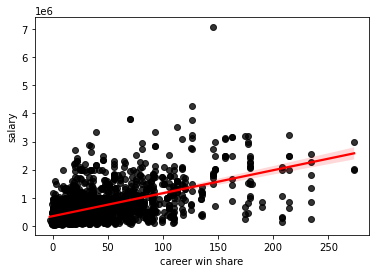

```python
#Period 1: 1985-1992
#Graph of Salary by Career Win Shares with Line of Best Fit
combineddf_p1 = pd.DataFrame()
for index, row in combined_df.iterrows():
  if(row['season'] in ["1985-86", "1986-87","1987-88","1988-89","1989-90","1990-91","1991-92"]):
    combineddf_p1 = combineddf_p1.append(row)
x = (combineddf_p1['career_WS'].values).astype(float)
y = (combineddf_p1['salary'].values).astype(float)
ax1 = sns.regplot(x, y, scatter_kws={"color": "black"}, line_kws={"color": "red"})
ax1.set(xlabel='career win share', ylabel='salary')
plt.show()
```

For period 1, we can observe a positive relationship between salary and career win share, meaning that as salary increases, so does career win share.

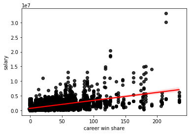

```python
#Period 2: 1992-1999
#Graph of Salary by Career Win Shares with Line of Best Fit
combineddf_p2 = pd.DataFrame()
for index, row in combined_df.iterrows():
  if(row['season'] in ["1992-93", "1993-94","1994-95","1995-96","1996-97","1997-98","1998-99"]):
    combineddf_p2 = combineddf_p2.append(row)
x2 = (combineddf_p2['career_WS'].values).astype(float)
y2 = (combineddf_p2['salary'].values).astype(float)
ax2 = sns.regplot(x2, y2, scatter_kws={"color": "black"}, line_kws={"color": "red"})
ax2.set(xlabel='career win share', ylabel='salary')
plt.show()
```

For period 2, we can observe a positive relationship between salary and career win share, meaning that as salary increases, so does career win share. However, this relationship is weaker than in period 1.

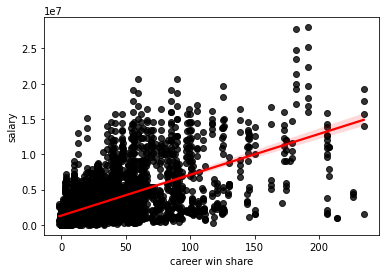

```python
#Period 3: 1999-2006
#Graph of Salary by Career Win Shares with Line of Best Fit
combineddf_p3 = pd.DataFrame()
for index, row in combined_df.iterrows():
  if(row['season'] in ["1999-00", "2000-01","2001-02","2002-03","2003-04","2004-05","2005-06"]):
    combineddf_p3 = combineddf_p3.append(row)
x3 = (combineddf_p3['career_WS'].values).astype(float)
y3 = (combineddf_p3['salary'].values).astype(float)
ax3 = sns.regplot(x3, y3, scatter_kws={"color": "black"}, line_kws={"color": "red"})
ax3.set(xlabel='career win share', ylabel='salary')
plt.show()
```

For period 3, we can observe a positive relationship between salary and career win share, meaning that as salary increases, so does career win share. This relationship is stronger than both periods 1 & 2.

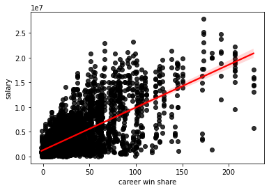

```python
#Period 4: 2006-2013
#Graph of Salary by Career Win Shares with Line of Best Fit
combineddf_p4 = pd.DataFrame()
for index, row in combined_df.iterrows():
  if(row['season'] in ["2006-07","2007-08","2008-09","2009-10","2010-11","2011-12","2012-13"]):
    combineddf_p4 = combineddf_p4.append(row)
x4 = (combineddf_p4['career_WS'].values).astype(float)
y4 = (combineddf_p4['salary'].values).astype(float)
ax4 = sns.regplot(x4, y4, scatter_kws={"color": "black"}, line_kws={"color": "red"})
ax4.set(xlabel='career win share', ylabel='salary')
plt.show()
```

For period 4, we can observe a positive relationship between salary and career win share, meaning that as salary increases, so does career win share. This relationship is stronger than all previous periods.

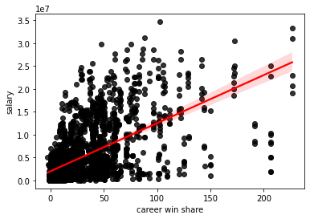

```python
#Period 5: 2013-2018
#Graph of Salary by Career Win Shares with Line of Best Fit
combineddf_p5 = pd.DataFrame()
for index, row in combined_df.iterrows():
  if(row['season'] in ["2013-14","2014-15","2015-16","2016-17","2017-18"]):
    combineddf_p5 = combineddf_p5.append(row)
x5 = (combineddf_p5['career_WS'].values).astype(float)
y5 = (combineddf_p5['salary'].values).astype(float)
ax5 = sns.regplot(x5, y5, scatter_kws={"color": "black"}, line_kws={"color": "red"})
ax5.set(xlabel='career win share', ylabel='salary')
plt.show()
```

For period 5, we can observe a positive relationship between salary and career win share, meaning that as salary increases, so does career win share. This relationship is stronger than all previous periods.

What can we observe?

Throughout all the periods, a positive relationship between salary and career win share was observed, suggesting that as salary increases, so does career win share. This affirms our hypothesis that having a greater salary will correlate to a player contributing to more wins.

Let's look at the salaries and wins of players individually.

```python
# Extract top ten highest-paid players
total_sal = combined_df.groupby('_id')['salary'].sum().to_dict()
total_sal = pd.DataFrame.from_dict(total_sal, orient='index', columns=['Total Salary'])

#for index, row in df_marks.iterrows():
top_ten_sal = total_sal.nlargest(10, 'Total Salary')
#top_ten_ws = total_ws.nlargest(10, 'Total WS')
top_ten_sal
```

|  | Total Salary |
| --- | --- |
| garneke01 | 343872398 |
| bryanko01 | 328238062 |
| onealsh01 | 292198327 |
| nowitdi01 | 250371801 |
| duncati01 | 243471655 |
| jamesle01 | 237020472 |
| anthoca01 | 232001415 |
| johnsjo02 | 220040806 |
| boshch01 | 215272333 |
| howardw01 | 213765862 |

The above code utilizes the pandas "nlargest" function to create a new data frame of ten entries representing the top 10 highest paid NBA players between the years of 1985 and 2018. Here they are listed in descending order:

1. Kevin Garnett
2. Kobe Bryant
3. Shaquille O'Neal
4. Dirk Nowitzki
5. Tim Duncan
6. Lebron James
7. Carmelo Anthony
8. Joe Johnson
9. Chris Bosh
10. Dwight Howard

After creating this dataframe, we can see household names such as Kobe Bryant, Lebron James, and Chris Bosh have made the list of top 10 highest-paid players within a 33 year period. From a statistical standpoint, this definitely reaffirms their success in the sport. Using this data, we can analyze how the amount a player contributes to their team wining affects their salary. Lets see if we can find a relationship between the salaries of the top ten highest played NBA players for our time frame (1985-2018) and their winshares.

**How do we visualize the relationship between a player's salary and winshare?** Lets use a linear regression model!

```python
# Get total winshares for all players in dataset and create a new dataframe
combined_df['career_WS'] = combined_df['career_WS'].astype(float)
total_ws = combined_df.groupby('_id')['career_WS'].sum().to_dict()
total_ws = pd.DataFrame.from_dict(total_ws, orient='index', columns=['Total Win Shares'])
total_ws

highest_paid = pd.merge(top_ten_sal, total_ws, how='inner', right_index= True, left_index=True)
highest_paid
```

|  | Total Salary | Total Win Shares |
| --- | --- | --- |
| garneke01 | 343872398 | 4210.8 |
| bryanko01 | 328238062 | 3454.0 |
| onealsh01 | 292198327 | 3452.3 |
| nowitdi01 | 250371801 | 4126.0 |
| duncati01 | 243471655 | 4334.4 |
| jamesle01 | 237020472 | 3399.0 |
| anthoca01 | 232001415 | 1515.0 |
| johnsjo02 | 220040806 | 1573.2 |
| boshch01 | 215272333 | 1590.0 |
| howardw01 | 213765862 | 1804.6 |

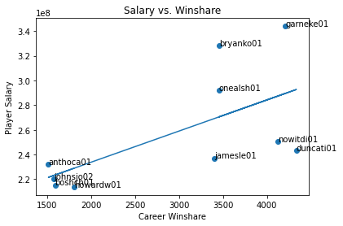

```python
# Create salary, winshare, and player ID arrays for plotting
x = highest_paid['Total Win Shares'].array
y = highest_paid['Total Salary'].array
n = highest_paid.index

# Get linear regression stats for winshares vs. salary
slope, intercept, r, p, std_err = stats.linregress(x, y)

# Using slope and intercept stats, get y values for the line of linear regression by running x values through
# slope-intercept formula
def myfunc(x):
  return slope * x + intercept
mymodel = list(map(myfunc, x))

# Plot salary vs. winshares and draw best fit line
plt.scatter(x, y)
plt.plot(x, mymodel)

# Add title and axis labels
plt.title("Salary vs. Winshare")
plt.ylabel("Player Salary")
plt.xlabel("Career Winshare")

# Label each point on the plot with the corresponding player ID
for i, txt in enumerate (n):
    plt.text(x[i], y[i], txt)

plt.show()
```

The linear regression model shows a positive linear relationship between a player's total winshare and their salary. So, we can probably assume that the more wins a player contributes to their team, the higher they will be paid. *How* good of a relationship is there between salary and winshare, though? That is, how well does total winshare predict a player's salary?

```python
print(r)
```

```
0.6346099337343292
```

The coefficient of correlation, *r*, which is calculated by the stats() function, indicates how well the two variables correlate. A value of 0.63 is relatively high and indicates that there is a moderately good relationship between winshare and salary. Therefore, winshare is a moderately good predictor for a player's salary, and one can assume that highly paid players have higher win shares.

**Which players have the highest number of wins?** Presumably, the players with the highest number of wins would be the ones with the highest number of winshares, because that means they have contributed the most to their teams winning the season. Lets create another dataframe of the top ten players with the highest winshares and see if there are any parallels with the top ten highest paid players.

```python
top_ten_ws = total_ws.nlargest(10, "Total Win Shares")
top_ten_ws
```

|  | Total Win Shares |
| --- | --- |
| duncati01 | 4334.4 |
| malonka01 | 4222.8 |
| garneke01 | 4210.8 |
| nowitdi01 | 4126.0 |
| stockjo01 | 3530.9 |
| bryanko01 | 3454.0 |
| onealsh01 | 3452.3 |
| jamesle01 | 3399.0 |
| jordami01 | 3210.0 |
| millere01 | 3139.2 |

```python
highest_ws = pd.merge(top_ten_ws, total_sal, how='inner', right_index= True, left_index=True)
highest_ws
```

|  | Total Win Shares | Total Salary |
| --- | --- | --- |
| duncati01 | 4334.4 | 243471655 |
| malonka01 | 4222.8 | 105933378 |
| garneke01 | 4210.8 | 343872398 |
| nowitdi01 | 4126.0 | 250371801 |
| stockjo01 | 3530.9 | 67753000 |
| bryanko01 | 3454.0 | 328238062 |
| onealsh01 | 3452.3 | 292198327 |
| jamesle01 | 3399.0 | 237020472 |
| jordami01 | 3210.0 | 93285000 |
| millere01 | 3139.2 | 104522748 |

```python
combine_ws_sal = pd.merge(top_ten_ws, top_ten_sal, how='inner', right_index= True, left_index=True)
combine_ws_sal
```

|  | Total Win Shares | Total Salary |
| --- | --- | --- |
| duncati01 | 4334.4 | 243471655 |
| garneke01 | 4210.8 | 343872398 |
| nowitdi01 | 4126.0 | 250371801 |
| bryanko01 | 3454.0 | 328238062 |
| onealsh01 | 3452.3 | 292198327 |
| jamesle01 | 3399.0 | 237020472 |

To find the players that both datasets have in common, we can merge the top ten winshares and top ten salaries dataframes. Of 10 players, both datasets have 6 players in common. They are ordered in the merged dataframe by total number of winshares. As we can see, the players with higher win shares do not necessarily make more than players with lower win shares. For example, Nowitzki has a higher total win share than Kobe, but made less money overall than Kobe did during this time period. The same goes for Duncan and Garnett- Duncan has contributed more wins to his team, but made less than Garnett, who as we have seen from the top ten salaries dataframe, was paid the best of all the players in the dataset.

As the correlation coefficient suggested, a player's total win shares is a pretty good predictor of their salary, but it is not perfect. In other words, there exists a considerable positive correlation between winshares and salaries, but a higher number of win shares certainly does not translate to a higher salaries. Clearly, other factors are at play when determining a player's total salaries, not just win shares.

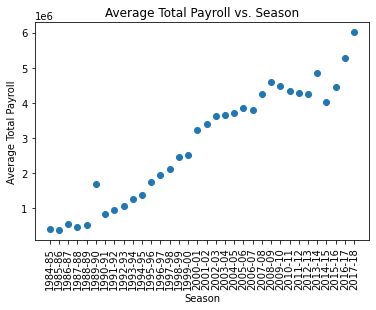

```python
# Sort dataframe by season (sorts from most recent --> least recent)
combined_df['sort'] = combined_df['season'].str.extract('(\d+)', expand=False).astype(int)
combined_df.sort_values('sort',inplace=True, ascending=False)
combined_df = combined_df.drop('sort', axis=1)

# Use pandas transform() function to compute average salaries over all players for each season
combined_df['mean'] = combined_df.groupby('season')["salary"].transform('mean')

# Drop repeated season and average values, reverse arrays so they are in ascending order instead of descending
x = combined_df['season'].drop_duplicates().iloc[::-1].array
y = combined_df['mean'].drop_duplicates().iloc[::-1].array

# Plot average total salary over season
plt.scatter(x, y)

# Add title and axis labels
plt.title("Average Total Payroll vs. Season")
plt.xlabel("Season")
plt.ylabel("Average Total Payroll")
# Rotate axis labels and resize
plt.xticks(rotation=90)
figure(figsize=(15, 10), dpi=100)

plt.show()
```

One extenuating factor that could affect a player's salary that we can explore is time. Using pandas, we can sort our dataframe by season and then calculate the total payroll for ALL players in each season and average that value out. A trend line is not even needed to see that average total payroll increases steadily over time. Clearly, the time period affects how well a player is paid. Lets think about the top ten winshares data frame. One player who makes that list is Michael Jordan, who was in his prime during the '90s. However, he does not make the top 10 highest paid players list because he played during a time period where the NBA did not pay their players as well, relative to more recent seasons. Total win share is a pretty good quantitative metric for a player's skill. As shown by this plot, skill is not the only factor that determine's a player's salary, though it definitely plays a role. Lets find the correlation coefficient for season and salary to figure out if time is a better predictor of salary than winshare/skill. To do this, we will need to change the datatype of the "season" column, which is currently a string.

```python
# Loop through array of seasons, truncate string at "-", convert to float
idx = 0
for s in x:
    s = s.split("-")
    x[idx] = float(s[0])
    idx +=1

# Get linear regression stats for average total payroll vs. year
slope, intercept, r, p, std_err = stats.linregress(x.astype(float), y)

# Using slope and intercept stats, get y values for the line of linear regression
# by running x values through slope-intercept formula
def myfunc(x):
  return slope * x + intercept
mymodel = list(map(myfunc, x))

# Print coefficient of correlation
print(r)
```

```
0.9713006158162731
```

# **Hypothesis Testing**

To see if our hypothesis that having a greater salary will correlate to a player contributing to more wins, we can do hypothesis testing.

First, we will do a Pearson's Correlation Coefficient test, which can help us see if there's a linear relationship/correlation between salary and career win share.

```python
from scipy.stats import pearsonr
sal_data = combined_df['salary']
ws_data = list(map(float, (combined_df['career_WS'])))
stat1, p1 = pearsonr(sal_data, ws_data)
print('stat=%.3f, p=%.3f' % (stat1, p1))
if p1 <= 0.05:
 print('Likely dependent')
else:
 print('Likely independent')
```

```
stat=0.464, p=0.000
Likely dependent
```

Null Hypothesis: the two sets are independent

Alternative Hypothesis: there's a dependency between the sets

Based on the pearson's correlation coefficient test, the p-value is less than 0.05, meaning there is insufficient evidence to prove the null hypothesis that salary and career win share are independent of each other, therefore this test indicates they are likely dependent on each other, in other words a (linear) relationship. The positive statistic also indicates it's a positive linear relationship.

Let's do some more testing; below we are doing a Kendall’s Rank Correlation, which tests for a monotonic relationship between the variables.

```python
from scipy.stats import kendalltau
stat2, p2 = kendalltau(sal_data, ws_data)
print('stat=%.3f, p=%.3f' % (stat2, p2))
if p2 <= 0.05:
 print('Likely dependent')
else:
 print('Likely independent')
```

```
stat=0.363, p=0.000
Likely dependent
```

Null Hypothesis: the two sets are independent

Alternative Hypothesis: there's a dependency between the sets

Based on the Kendall’s Rank Correlation test, the p-value is less than 0.05, meaning there is insufficient evidence to prove the null hypothesis that salary and career win share are independent of each other, therefore this test indicates they are likely dependent on each other, in other words a (monotonic) relationship. The positive statistic also indicates it's a positive monotonic relationship.

Let's do another test to corroborate or deaffirm this; Spearman’s Rank Correlation test will be performed below, which tests for a monotonic relationship between variables.

```python
from scipy.stats import spearmanr
stat3, p3 = spearmanr(sal_data, ws_data)
print('stat=%.3f, p=%.3f' % (stat3, p3))
if p3 <= 0.05:
 print('Likely dependent')
else:
 print('Likely independent')
```

```
stat=0.519, p=0.000
Likely dependent
```

Null Hypothesis: the two sets are independent

Alternative Hypothesis: there's a dependency between the sets

Based on the Spearman’s Rank Correlation test, the p-value is less than 0.05, meaning there is insufficient evidence to prove the null hypothesis that salary and career win share are independent of each other, therefore this test indicates they are likely dependent on each other, in other words a (monotonic) relationship. The positive statistic also indicates it's a positive monotonic relationship.

In summary, based on our hypothesis testing, results indicate that our hypothesis that having a greater salary will correlate to a player contributing to more wins has evidence to support it. All the tests indicate that there is a relationship/dependency between salary and career win shares, with the Kendall’s Rank Correlation test and the Spearman’s Rank Correlation specifically indicating a monotonic relationship, in other words the relationship/correlation observed is that as salary increases, so does career win share for that player.

# **Communication of Insights Attained**

There is one certain trend that salary increases as a measure of time. Moreover, our analysis over time indicates that the time period has more of an impact on player salary than "skill" or advanced statistics such as Win Shares or an Efficiency Rating. Using the Pearson's Correlation Coefficient test and the Spearman’s Rank Correlation test we are able to deduce that most of the time, a greater salary is correlated to a player contributing to more wins. This is shown through Career Win Shares. Initially, our analysis of mode, median, and average players shows that the highest paid player would not have the highest win share. This is evident, but we have found that rather there is a general correlation rather than absolute.